# HW 5

### Enter your name and EID here: srs5826

**You will submit this homework assignment as a HTML file on Canvas.**

*For all questions, include the R commands/functions that you used to find your answer (show R chunk). Answers without supporting code will not receive credit. Write full sentences to describe your findings.*

### Question 1: (1 pt)

The dataset `world_bank_pop` is a built-in dataset in `tidyverse`. It contains information about total population and population growth, overall and more specifically in urban areas, for countries around the world. Take a look at it with `head()`. Is the data tidy? Why or why not?

```r
# Call tidyr, dplyr and ggplot2 packages within tidyverse
library(tidyverse)

# Take a look!
head(world_bank_pop)
```

```
## # A tibble: 6 × 20
##   country indicator       `2000`  `2001`  `2002`  `2003`  `2004`  `2005`  `2006`
##   <chr>   <chr>            <dbl>   <dbl>   <dbl>   <dbl>   <dbl>   <dbl>   <dbl>
## 1 ABW     SP.URB.TOTL     4.16e4 4.20e+4 4.22e+4 4.23e+4 4.23e+4 4.24e+4 4.26e+4
## 2 ABW     SP.URB.GROW     1.66e0 9.56e-1 4.01e-1 1.97e-1 9.46e-2 1.94e-1 3.67e-1
## 3 ABW     SP.POP.TOTL     8.91e4 9.07e+4 9.18e+4 9.27e+4 9.35e+4 9.45e+4 9.56e+4
## 4 ABW     SP.POP.GROW     2.54e0 1.77e+0 1.19e+0 9.97e-1 9.01e-1 1.00e+0 1.18e+0
## 5 AFE     SP.URB.TOTL     1.16e8 1.20e+8 1.24e+8 1.29e+8 1.34e+8 1.39e+8 1.44e+8
## 6 AFE     SP.URB.GROW     3.60e0 3.66e+0 3.72e+0 3.71e+0 3.74e+0 3.81e+0 3.81e+0
## # ℹ 11 more variables: `2007` <dbl>, `2008` <dbl>, `2009` <dbl>, `2010` <dbl>,
## #   `2011` <dbl>, `2012` <dbl>, `2013` <dbl>, `2014` <dbl>, `2015` <dbl>,
## #   `2016` <dbl>, `2017` <dbl>
```

**The data is not tidy. Every cell is not a single observation, each column is not a different varaible, and every cell is not a single value.**

### Question 2: (1 pt)

Using `dplyr` functions on `world_bank_pop`, count how many distinct countries there are in the dataset. Does this makes sense? Why or why not?

```r
library(dplyr)

# get distinct countriws
distinct_countries <- world_bank_pop %>%
  distinct(country) %>%
  n_distinct()

# Print the count
distinct_countries
```

```
## [1] 266
```

**This does not make sense, because the approximate number of countries is around 195, and this count is 70 countries larger.**

### Question 3: (2 pts)

Use one of the `pivot` functions on `world_bank_pop` to create a new dataset with the years 2000 to 2017 appearing as a *numeric* variable `year`, and the different values for the indicator variable are in a variable called `value`. Save this new dataset in your environment as `myworld1`.

```r
#set dataset as myworld1
myworld1 <- world_bank_pop %>%
  pivot_longer(cols = starts_with("20"), # Select columns starting with "20" (the year columns)
               names_to = "year",          # Create a new column "year" for the years
               values_to = "value")        # Create a new column "value" for the values
```

How many lines are there per country? Why does it make sense?

```r
# use group_by then summarize to get lines
lines_per_country <- myworld1 %>%
  group_by(country) %>%
  summarize(number_of_lines = n())

lines_per_country
```

```
## # A tibble: 266 × 2
##    country number_of_lines
##    <chr>             <int>
##  1 ABW                  72
##  2 AFE                  72
##  3 AFG                  72
##  4 AFW                  72
##  5 AGO                  72
##  6 ALB                  72
##  7 AND                  72
##  8 ARB                  72
##  9 ARE                  72
## 10 ARG                  72
## # ℹ 256 more rows
```

**There are 72 lines per country. This makes sense because there is 4 indicator types and 18 different years and 4 * 18 is 72.**

### Question 4: (3 pts)

Use another `pivot` function on `myworld1` to create a new dataset, `myworld2`, with the different categories for the indicator variable appearing as their own variables. Use `dplyr` functions to rename `SP.POP.GROW` and `SP.URB.GROW`, as `pop_growth` and `pop_urb_growth` respectively.

```r
library(tidyr)

# Pivot wider
myworld2 <- myworld1 %>%
  pivot_wider(names_from = indicator, values_from = value)

# Rename columns
myworld2 <- myworld2 %>%
  rename(
    pop_growth = "SP.POP.GROW",
    pop_urb_growth = "SP.URB.GROW"
  )
```

Using `dplyr` functions, find the ratio of urban growth compared to the population growth in the world for each year. *Hint: the country code `WLD` represents the entire world.* Create a `ggplot` to display how the percentage of urban population growth has changed over the years. Why does your graph not contradict the fact that the urban population worldwide is increasing over the years?

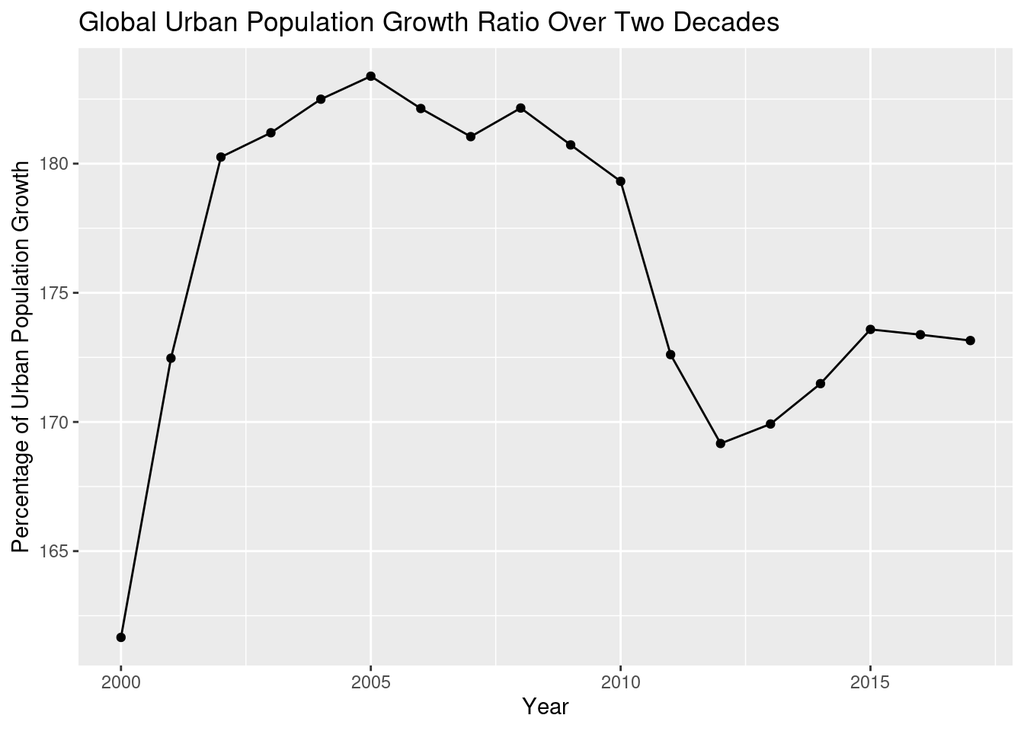

```r
library(ggplot2)

# Filter the dataset for the world (country code WLD)
world_data <- myworld2 %>%
  filter(country == "WLD")

# Calculate the percentage of urban population growth compared to total population growth
world_data <- world_data %>%
  mutate(urban_growth_ratio = (pop_urb_growth / pop_growth) * 100)

# Create a plot
ggplot(world_data, aes(x = as.numeric(year), y = urban_growth_ratio)) +
  geom_point() +
  geom_line() +
  labs(
    x = "Year",
    y = "Percentage of Urban Population Growth",
    title = "Global Urban Population Growth Ratio Over Two Decades"
  )
```

**This is a derivative graph of urban growth per population growth per year. A negative or 0 slope of the derivative graph just means that the population is growing at a slower rate, not decreasing.**

### Question 5: (1 pt)

In `myworld2`, which country code had the highest population growth in 2017?

```r
library(dplyr)

# Filter the dataset for  2017
pop_growth_2017 <- myworld2 %>%
  filter(year == 2017)

# Arrange the data in descending order
pop_growth_2017 <- pop_growth_2017 %>%
  arrange(desc(pop_growth))

# Get the first value
highest_growth_2017 <- pop_growth_2017$country[1]

# Print the country code
highest_growth_2017
```

```
## [1] "QAT"
```

**The highest pop growth country in 2017 was Qatar, which is honestly pretty surprising considering how developed it is. I thought it would be some African country or India. I’m guessing its all immigration.**

### Question 6: (1 pt)

When answering the previous, we only reported the three-letter code and (probably) have no idea what the actual country is. We will now use the package `countrycode` with a built-in dataset called `codelist` that has information about the coding system used by the World bank:

```r
# Paste and run the following into your console (NOT HERE): install.packages("countrycode")

# Call the countrycode package
library(countrycode)

# Create a list of codes with matching country names
mycodes <- codelist # continue this code...
```

Using `dplyr` functions, modify `mycodes` above to only keep the variables `continent`, `wb` (World Bank code), and `country.name.en` (country name in English). Then remove countries with missing `wb` code.

How many countries are there in `mycodes`?

```r
library(dplyr)

# select the 3 columns and filter NAs
mycodes <- mycodes %>%
  select(continent, wb, country.name.en) %>%  # Select the specified columns
  filter(!is.na(wb))  # Remove rows with missing wb codes

num_countries <- nrow(mycodes)

# Print the number of countries
num_countries
```

```
## [1] 218
```

**There is 218 countries in mycodes, which is closer to the 195 area but still a decent bit larger.**

### Question 7: (1 pt)

Use a `left_join()` function to add the information of the country codes **to** `myworld2` dataset. Match the two datasets based on the World Bank code. *Note: the World Bank code does not have the same name in each dataset.* Using `dplyr` functions, only keep the data available for Europe and for the year 2017. Save this new dataset as `myeurope`.

```r
# create myeurope from the filtered left join
myeurope <- myworld2 %>%
  left_join(mycodes, by = c("country" = "wb")) %>%
  filter(continent == "Europe" & year == 2017)
```

How many rows are there in `this new dataset`myeurope`? What does each row represent?

```r
#Use nrow
num_rows_myeurope <- nrow(myeurope)

num_rows_myeurope
```

```
## [1] 46
```

**There are 46 rows in myeurope and each row represents an individual country.**

### Question 8: (2 pts)

Using `dplyr` functions on `myeurope`, only keep information for the population growth in 2017 then compare the population growth per country with `ggplot` using `geom_bar()`. Make sure to order countries in order of population growth. Which country in Europe had the lowest population growth in 2017?

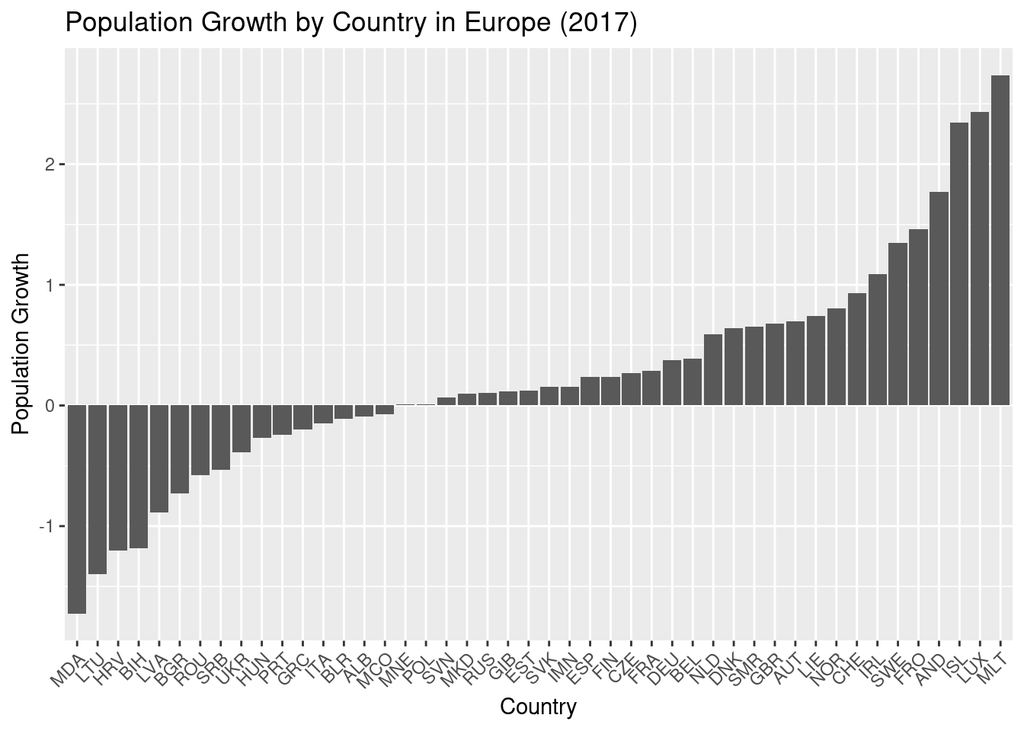

```r
# get lowest pop growth
lowest_pop_growth <- myeurope %>%
  filter(year == 2017) %>% # Filter for 2017
  select(country, pop_growth) %>% # Select country and population growth columns
  arrange(pop_growth) # Arrange in ascending order to get smallest

# Create a bar plot
ggplot(lowest_pop_growth, aes(x = reorder(country, pop_growth), y = pop_growth)) +
  geom_bar(stat = "identity") +
  labs(
    x = "Country",
    y = "Population Growth",
    title = "Population Growth by Country in Europe (2017)"
  ) +
  theme(axis.text.x = element_text(angle = 45, hjust = 1)) # Rotate labels so you can actually read them
```

**The country in europe with the least population growth is MDA, which I believe is Moldova. It had a negative growth, so people are leaving and dying faster than people immigrating and being born.**

### Question 9: (1 pt)

When dealing with location data, we can actually visualize information on a map if we have geographic information such as latitude and longitude. Next, we will use a built-in function called `map_data()` to get geographic coordinates about countries in the world (see below). Take a look at the dataset `mapWorld`. What variables could we use to join `mapWorld` and `myeurope`? *Note: the variables do not have the same name in each dataset but they contain the same information.*

```r
# Geographic coordinates about countries in the world
mapWorld <- map_data("world")
```

**We could join mapWorld and myeurope on country.name.eng = Region. The both have the same information.**

### Question 10: (2 pts)

Use a joining function to check if any information from `myeurope` is not contained in `mapWorld`, matching the two datasets based on the country name.

```r
library(dplyr)

# antijoin for unmatched data
unmatched_data <- anti_join(myeurope, mapWorld, by = c("country.name.en" = "region"))
```

Some countries such as United Kingdom did not have a match. Why do you think this happened? *Hint: find the distinct country names in `mapWorld`, arrange them in alphabetical order, and scroll through the names. Can you find any of these countries with no match in a slightly different form?*

```r
# get distnct
distinct_eu <- mapWorld %>%
  distinct(region) %>%  # Select the unique country names
  arrange(region)      # Arrange them in alphabetical order
```

**They are just named in different way. For example the ‘and’ in Bosnia & Herzegovina is a symbol in one table and ‘and’ in another.**